# Project: Soccer Fun! (Terri Jerez)

- Introduction
- Data Wrangling
- Exploratory Data Analysis
- Conclusions

## Introduction

I will be analyzing the Soccer database which comes from Kaggle and which I accessed using DB Browser for SQLite. I reviewed the data and asked the following questions:

1. Does the home team win more games than the away team?
2. What is the goal difference?

To analyze these questions, I will research amount of games played and determine what percentage of the matches were home team wins, which were away team wins, and which matches ended in a tie. I will then look to see what the goal difference is between home and away teams.

The dependent variable in my project is a win. The independent variables are: home team, away team, and amount of goals.

```python
# Downloading various packages to be used in the project

import numpy as np # linear algebra
import pandas as pd # data processing
import sqlite3
import matplotlib.pyplot as plt
import seaborn as sns
import pylab as pl
%matplotlib inline
```

```python
cnx=sqlite3.connect('database.sqlite')
```

## Data Wrangling

### First Steps

To begin my research, I looked through the tables in the dataset to determine which table would have relevant data in order to answer my question. I discovered the table "Matches" and saw that it had the data I needed.

```python
#First, I analyzed the matches table to see what data it contained
df = pd.read_sql_query("SELECT * FROM Match",cnx)
df.head()
```

|  | id | country_id | league_id | season | stage | date | match_api_id | home_team_api_id | away_team_api_id | home_team_goal | ... | SJA | VCH | VCD | VCA | GBH | GBD | GBA | BSH | BSD | BSA |
| --- | --- | --- | --- | --- | --- | --- | --- | --- | --- | --- | --- | --- | --- | --- | --- | --- | --- | --- | --- | --- | --- |
| 0 | 1 | 1 | 1 | 2008/2009 | 1 | 2008-08-17 00:00:00 | 492473 | 9987 | 9993 | 1 | ... | 4.00 | 1.65 | 3.40 | 4.50 | 1.78 | 3.25 | 4.00 | 1.73 | 3.40 | 4.20 |
| 1 | 2 | 1 | 1 | 2008/2009 | 1 | 2008-08-16 00:00:00 | 492474 | 10000 | 9994 | 0 | ... | 3.80 | 2.00 | 3.25 | 3.25 | 1.85 | 3.25 | 3.75 | 1.91 | 3.25 | 3.60 |
| 2 | 3 | 1 | 1 | 2008/2009 | 1 | 2008-08-16 00:00:00 | 492475 | 9984 | 8635 | 0 | ... | 2.50 | 2.35 | 3.25 | 2.65 | 2.50 | 3.20 | 2.50 | 2.30 | 3.20 | 2.75 |
| 3 | 4 | 1 | 1 | 2008/2009 | 1 | 2008-08-17 00:00:00 | 492476 | 9991 | 9998 | 5 | ... | 7.50 | 1.45 | 3.75 | 6.50 | 1.50 | 3.75 | 5.50 | 1.44 | 3.75 | 6.50 |
| 4 | 5 | 1 | 1 | 2008/2009 | 1 | 2008-08-16 00:00:00 | 492477 | 7947 | 9985 | 1 | ... | 1.73 | 4.50 | 3.40 | 1.65 | 4.50 | 3.50 | 1.65 | 4.75 | 3.30 | 1.67 |

5 rows × 115 columns

```python
#This code shows the shape of the dataframe

df.shape
```

[output not shown]

By executing the shape command I discovered that 25979 matches were played. I wanted to see the number of rows and columns with the purpose of finding out the total number of games and what attributes each match had recorded. I noticed there was a column with home team goals and another one with away team goals. This is how I will be able to determine home team wins, away team wins and tied games in order to answer my question.

```python
#Next I wanted to gather more information about the matches specifically
df.describe()
```

[output not shown]

In reviewing this data, I realized that the only pertinent columns for my project and question are the "home_team_goal", "away_team_goal", and the total number of matches that I obtained by doing a query on the id column

```python
#Next, I gathered the total number of matches

df = pd.read_sql_query("SELECT COUNT(id)FROM Match", cnx)
df.head()
```

|  | COUNT(id) |
| --- | --- |
| 0 | 25979 |

```python
#Now I want to see how many home team wins there were
#I ran a SELECT query that compares how many instances the home team had more goals than the away team

df = pd.read_sql_query("SELECT COUNT(*)FROM match WHERE home_team_goal > away_team_goal", cnx)
df.head()
```

|  | COUNT(*) |
| --- | --- |
| 0 | 11917 |

```python
#Then I needed to see how many away team wins there were.
#I again ran a SELECT query that compares how many instances the away team had more goals than the home team

df = pd.read_sql_query("SELECT COUNT(*)FROM match WHERE home_team_goal < away_team_goal", cnx)
df.head()
```

|  | COUNT(*) |
| --- | --- |
| 0 | 7466 |

```python
#Finally how many tied games?
# Here I ran a SELECT query to see how many instances the home team and the away team had an equal amount of goals

df = pd.read_sql_query("SELECT COUNT(*)FROM match WHERE home_team_goal = away_team_goal", cnx)
df.head()
```

|  | COUNT(*) |
| --- | --- |
| 0 | 6596 |

The previous three code cells give me the information I need to answer my first main question of "Does the home team win more games than the away team?" The home team wins are 11917, the away team wins are 7466, and the amount of tie games are 6596.

The next cells look at the amounts of goals scored by the home team and the away team, information I will need to look at the goal difference

```python
#Total number of goals by home team
df = pd.read_sql_query("SELECT SUM(home_team_goal)FROM Match", cnx)
df.head()
```

|  | SUM(home_team_goal) |
| --- | --- |
| 0 | 40127 |

```python
# total number of goals by the Away Teams to compare the difference

df = pd.read_sql_query("SELECT SUM(away_team_goal)FROM Match", cnx)
df.head()
```

|  | SUM(away_team_goal) |
| --- | --- |
| 0 | 30160 |

### CLEANING UP THE DATA

In general, the data I need for my question looks pretty clean.

The number of goals are straightforward and the away team wins, home team wins, and ties add up to the total number of games played. There are many columns I don't need in order to analyze my data. In cleaning the data up I will drop those columns from the data set and I will look to see if there are any null or missing values

```python
df.isnull().sum(axis=0)
```

[output not shown]

```python
rows=df.shape[0]
df=df.dropna()
```

```python
print(rows)
df.isnull().any().any(),df.shape
```

[output not shown]

[output not shown]

```python
rows - df.shape[0]
```

```
0
```

```python
df = pd.read_sql_query("SELECT * FROM Match",cnx)
```

# Data cleaning, ctd.

```python
#Dropping rows that don't contain relevant information
#df = pd.read_sql_query("SELECT * FROM Match",cnx)
df.drop(df.columns[[1,2,3,4,5,6,7,8,11,12,13,14,15,16,17,18,19,20,21,22,23,24,25,26,27,28,29,30,31,32,33,34,35,36,37]], axis=1, inplace=True)#This command drops rows we don't need
df.drop(df.columns[[3,4,5,5,6,7,8,9,10,11,12,13,14,15,16,17,18,19,20]], axis=1, inplace=True)#This command drops rows we don't need
df.drop(df.columns[[4,5,6,7,8,11,12,13,14,15,16,17,18,19,20]], axis=1, inplace=True)#This command drops rows we don't need
df.drop(df.columns[[3,4,5,6,7,8,11,12,13,14,15,16,17,18,19,20]], axis=1, inplace=True)#This command drops rows we don't need
df.drop(df.columns[[3,4,5,6,7,8,11,12,13,14,15,16,17,18,19,20]], axis=1, inplace=True)
df.drop(df.columns[[3,4,5,6,7,8,11,12,13,14]], axis=1, inplace=True)
#df.drop(df.columns[[1]], axis=1, inplace=True)
df.head(20)
df.sum()
```

```
id                3.374672e+08
home_team_goal    4.012700e+04
away_team_goal    3.016000e+04
GBH               3.538749e+04
GBD               5.166565e+04
dtype: float64
```

```python
df.shape
```

```
(25979, 5)
```

```python
df.drop(df.columns[[0,3,4]], axis=1, inplace=True)
```

```python
df.head(20)
```

|  | home_team_goal | away_team_goal |
| --- | --- | --- |
| 0 | 1 | 1 |
| 1 | 0 | 0 |
| 2 | 0 | 3 |
| 3 | 5 | 0 |
| 4 | 1 | 3 |
| 5 | 1 | 1 |
| 6 | 2 | 2 |
| 7 | 1 | 2 |
| 8 | 1 | 0 |
| 9 | 4 | 1 |
| 10 | 1 | 2 |
| 11 | 0 | 2 |
| 12 | 0 | 0 |
| 13 | 2 | 2 |
| 14 | 1 | 2 |
| 15 | 0 | 1 |
| 16 | 1 | 3 |
| 17 | 1 | 3 |
| 18 | 2 | 3 |
| 19 | 0 | 0 |

This concludes the data cleaning portion of my project. I dropped the columns that were not necessary to answer my questions, making it easier to explore the data and analyze it. I also checked for null values.

## Exploratory Data Analysis

### Research Question 1 Does the home team win more games than the away team?

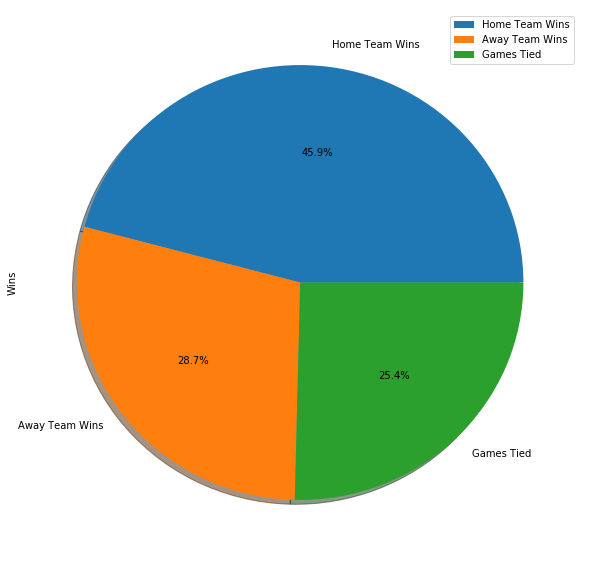

```python
#This pie chart shows the amount of home team wins, away team wins, and tied games
df = pd.DataFrame({'Wins':[11917,7466,6596]}, index=['Home Team Wins', 'Away Team Wins', 'Games Tied'])

plot = df.plot.pie(y='Wins', figsize=(10,10),autopct='%1.1f%%', shadow=True,)
```

The home team had more wins than the away team. 45.9% of the games won were won by a home team, whereas 28.7% of the games won were won by the away team. 25.4% of the games ended in a tie.

### Research Question 2 (What is the goal difference?)

After seeing the percentages of home team wins compared to away team wins, I was also interested in looking at the goal difference between the home team and away team to get an idea of how many more goals the home team scored compared to the away team and if there was any significance with the numbers.

```python
#Total number of goals between home team and away team from matches combined
#df = pd.read_sql_query("SELECT *, (home_team_goal + away_team_goal)FROM Match",cnx)
home_team_goal= 40127
away_team_goal = 30160
global_goal_addition = home_team_goal + away_team_goal
print ('Total goals scored is:',global_goal_addition)
```

```
Total goals scored is: 70287
```

```python
# Calculate goal difference
#df = pd.read_sql_query("SELECT *, (home_team_goal - away_team_goal)FROM Match",cnx)

home_team_goal= 40127
away_team_goal = 30160
global_goal_difference = home_team_goal - away_team_goal
print ('Goal Difference is:',global_goal_difference)
```

```
Goal Difference is: 9967
```

[figure not shown]

[figure not shown]

```python
#Visualize home and away goals

df = pd.read_sql_query("SELECT away_team_goal, home_team_goal FROM match", cnx)
df.columns=['Home Goals','Away Goals']

axarr = df.hist(column=('Home Goals'), sharex=True, sharey=True, layout = (1, 1))

for ax in axarr.flatten():
    ax.set_xlabel("Goals Per Game")
    ax.set_ylabel("Total Games")

axarr = df.hist(column=('Away Goals'), sharex=True, sharey=True, layout = (1, 1))

for ax in axarr.flatten():
    ax.set_xlabel("Goals Per Game")
    ax.set_ylabel("Total Games")
```

The next cells look at the correlation between home team goals and away team goals and the number of overall goals scored

```python
#correlation coeffecient of home team goals with total number of goals
import numpy as np
from scipy.stats import spearmanr
df= pd.read_sql_query("SELECT (home_team_goal+away_team_goal),(home_team_goal) FROM match", cnx)
df.head()
print(df.corr())#correlation
```

```
                                 (home_team_goal+away_team_goal)  \
(home_team_goal+away_team_goal)                         1.000000
home_team_goal                                          0.731828

                                 home_team_goal
(home_team_goal+away_team_goal)        0.731828
home_team_goal                         1.000000
```

This shows a strong positive correlation between home team goals and the overall number of goals scored between home and away teams.

```python
# correlation coeffecient of away team goals with total number of goals
import numpy as np
from scipy.stats import spearmanr
df= pd.read_sql_query("SELECT (home_team_goal+away_team_goal),(away_team_goal) FROM match", cnx)
df.head()
print(df.corr())#correlation
```

```
                                 (home_team_goal+away_team_goal)  \
(home_team_goal+away_team_goal)                         1.000000
away_team_goal                                          0.633179

                                 away_team_goal
(home_team_goal+away_team_goal)        0.633179
away_team_goal                         1.000000
```

This shows a moderately postive correlation between away team goals and overall team goals scored by both away and home teams.

## Conclusion

In reviewing the data from the information I gatherered, there were more games won by the home team than the away team. 45.9% of wins were from the home team, 28.7% from the away team, and 25.4% that ended in a tie. In this case, "home court advantage" seems to be a definite advantage. Also, more goals were scored by the home team when compared to goals scored by the away team.

Limitations to the exploartion for this project include: The data was only anazlyzed from European teams indicating that the home court advantage may not always apply to other leagues in other countries. Also, it was anazlyzed over a certain time period and other time periods may not yield the same results. Also, we don't know how far each team had to travel each time they played, what the time difference between areas and countries was, or how much time the away team had to adjust.